# multiScaleR User Guide

Bill Peterman

# 1 Background

Many abiotic and ecological processes are a result of variables operating at multiple scales. Such multiscale ecological processes can be challenging to quantify, especially when the surrounding landscape contributes to the process. The extent and magnitude of contribution from the surrounding landscape is often referred to as the ‘scale of effect’. Determining the scales of effect has long been the focus of ecologists seeking to address multiscale ecological questions, but until recently, methods to rigorously and can identify such scales have been lacking. With advanced coding skills, Bayesian analytical frameworks can be used (e.g., Stuber & Gruber 2020; Amirkhiz et al. 2023). More recently, user-friendly methods, implemented in R, have been developed (`Siland`: Carpentier & Martin 2021; `Scalescape`: Lowe et al. 2022). Both of these packages, like `multiScaleR`, estimate distance-weighted landscape effects (i.e. scales of effect). All take a similar approach to achieving this goal, but each works with different model classes and have different functions available to users.

`multiScaleR` is fully supported in handling models of class `glm`, `glm.nb`, `nlme` (including `gls`), `lme4`, and `unmarked`. It should work with any model class that has an `update` function and that is a supported class in the R package insight. This package has been developed to provide an efficient modeling workflow, facilitating scaling of rasters and spatial projections of optimized models. Let me know if you encounter issues or would like to see support for other model classes.

**References**

- Amirkhiz, R. G., R. John, and D. L. Swanson. 2023. A Bayesian approach for multiscale modeling of the influence of seasonal and annual habitat variation on relative abundance of ring-necked pheasant roosters. Ecological Informatics 75:102003.
- Carpentier, F., and O. Martin. 2021. Siland a R package for estimating the spatial influence of landscape. Scientific Reports 11:7488.
- Lowe, E. B., B. Iuliano, C. Gratton, and A. R. Ives. 2022. ‘Scalescape’: an R package for estimating distance-weighted landscape effects on an environmental response. Landscape Ecology 37:1771–1785.
- Stuber, E. F., and L. F. Gruber. 2020. Recent methodological solutions to identifying scales of effect in multi-scale modeling. Current Landscape Ecology Reports 5:127–139.

# 2 Distance-weighted Effects

There are *many* different kernel transformations that could be used to quantify the contribution of environmental variables as a function of distance. Four kernel functions are implemented in `multiScaleR` . Experience with simulated data suggests that the Exponential Power kernel, while flexible, is prone to over fitting and optimization often fails to converge. The Gaussian kernel is the default with `multiScaleR`. Note: Figures in this document rendered poorly. Re-running code on your local machine will provide much better results!

1. Gaussian (`gaus`) – Decay in space governed by a single parameter (sigma)

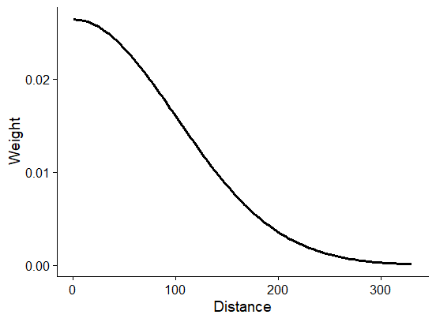

2. Negative Exponential (`exp`) – Decay in space governed by a single parameter (sigma)

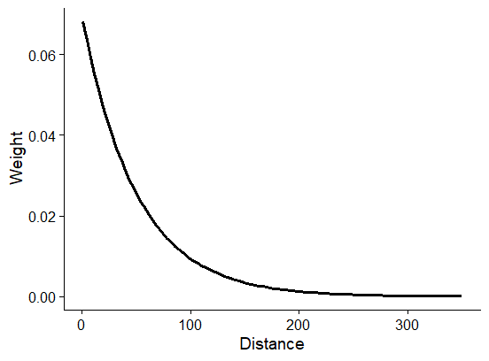

3. Exponential Power (`expow`) – Decay in space governed by a scale parameter (sigma), and shape parameter (beta)

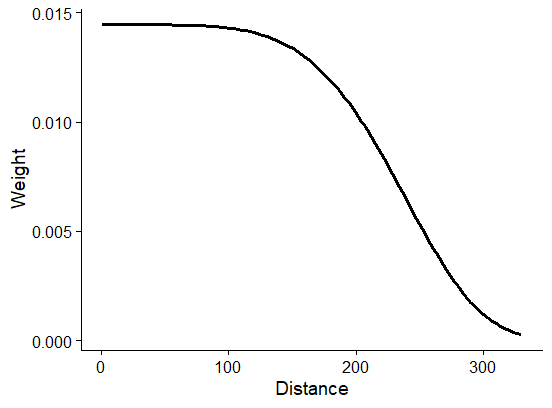

4. Fixed width buffer (`fixed`) – Effect does not decay with distance

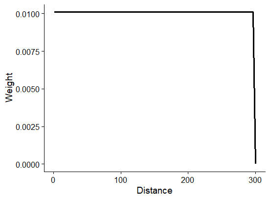

# 3 Preparing Data

Prior to using `multiScaleR` to identify distance-weighted scales of effect, data must be appropriately formatted. These steps will be demonstrated with simulated data provided with the package.

```r
library(multiScaleR)

## Read in data
data("landscape_counts")
dat <- landscape_counts

data("surv_pts")
pts <- vect(surv_pts)

land_rast <- terra::rast(system.file("extdata",
                                     "landscape.tif",
                                     package = 'multiScaleR'))
```

The `landscape_counts` data frame contains simulated counts from 100 spatial point locations as well as a scaled and centered site-level covariate (‘site’). The `landscape.tif` file is a `spatRaster` object consisting of three surfaces (land1 = binary habitat; land2 = continuous habitat / environment; land3 = continuous / environment). The counts were simulated using the following parameters:

- Poisson process
  - Intercept (alpha) of regression –> **0.25**
- `site`
  - Effect –> **0.3**
- `land1`
  - Effect –> **-0.5**
  - Gaussian sigma –> **250**
- `land2`
  - Effect –> **0.7**
  - Gaussian sigma –> **500**
- `land3`
  - Effect –> **0** (does not affect counts)

## 3.1 Explore Data

```r
summary(dat)
```

```
##      counts        site
##  Min.   : 0   Min.   :-1.7129
##  1st Qu.: 0   1st Qu.:-0.6480
##  Median : 1   Median :-0.1697
##  Mean   : 2   Mean   : 0.0000
##  3rd Qu.: 3   3rd Qu.: 0.5189
##  Max.   :10   Max.   : 2.9984
```

```r
pts
```

```
##  class       : SpatVector
##  geometry    : points
##  dimensions  : 100, 1  (geometries, attributes)
##  extent      : 755.3902, 3552.415, 755.3902, 3552.415  (xmin, xmax, ymin, ymax)
##  coord. ref. :
##  names       :   obs
##  type        : <int>
##  values      :     0
##                    3
##                    7
```

```r
land_rast
```

```
## class       : SpatRaster
## size        : 200, 200, 3  (nrow, ncol, nlyr)
## resolution  : 20, 20  (x, y)
## extent      : 0, 4000, 0, 4000  (xmin, xmax, ymin, ymax)
## coord. ref. :
## source      : landscape.tif
## names       : land1, land2, land3
## min values  :     0,     0,     0
## max values  :     1,     1,     1
```

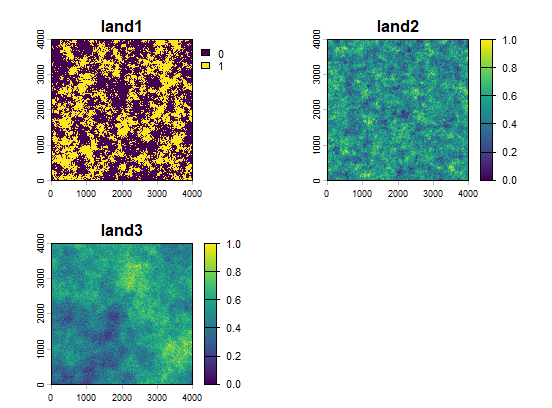

```r
plot(land_rast)
```

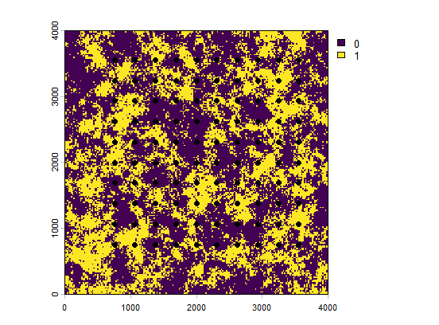

```r
## Plot with points
plot(land_rast$land1)
plot(pts, add = T, pch = 19)
```

## 3.2 `kernel_prep`

To begin an analysis, the `kernel_prep` function must be run with the `spatRaster` layers and spatial point data. Additionally, it is necessary to specify the maximum distance (in raster map units) that you want to consider in the analysis. The greater the distance considered, the more computationally intensive the analysis will be, so some consideration and discretion is needed. If the maximum distance appears to be constraining the optimization results, you will receive a warning.

```r
kernel_inputs <- kernel_prep(pts = pts,
                             raster_stack = land_rast,
                             max_D = 1700,
                             kernel = 'gaussian',
                             verbose = FALSE)
kernel_inputs
```

```
##
## There are 100 observations at 3 spatial covariate(s):
## land1 land2 land3
##
## The specified kernel is:
## gaussian
##
## Number of elements:
## 13111
## Minimum Distance:
## 20
## Maximum Distance:
## 1700
## Unit Conversion:
## 1700
```

Next, you need to fit the preliminary model that will serve as the starting point for optimizing scales of effect. We will pull raster values from the newly created `kernel_inputs` then fit a GLM. These raster value are scaled and centered weighted mean values for each layer, at each point.

```r
df <- data.frame(dat,
                 kernel_inputs$kernel_dat)
str(df)
```

```
## 'data.frame':    100 obs. of  5 variables:
##  $ counts: int  0 2 7 3 2 0 2 1 1 1 ...
##  $ site  : num  0.992 1.992 0.3 -0.623 1.891 ...
##  $ land1 : num  0.959 0.565 -0.132 -0.73 1.238 ...
##  $ land2 : num  -0.15 0.726 0.513 0.623 0.958 ...
##  $ land3 : num  0.6937 0.9235 0.455 -0.0789 1.0492 ...
```

Fit Poisson GLM

```r
mod0 <- glm(counts ~ site + land1 + land2 + land3,
            family = poisson(),
            data = df)
summary(mod0)
```

```
##
## Call:
## glm(formula = counts ~ site + land1 + land2 + land3, family = poisson(),
##     data = df)
##
## Coefficients:
##             Estimate Std. Error z value Pr(>|z|)
## (Intercept)  0.52794    0.08307   6.355 2.08e-10 ***
## site        -0.02191    0.11116  -0.197    0.844
## land1       -0.38930    0.08881  -4.383 1.17e-05 ***
## land2        0.77890    0.14288   5.451 5.00e-08 ***
## land3        0.09565    0.13016   0.735    0.462
## ---
## Signif. codes:  0 '***' 0.001 '**' 0.01 '*' 0.05 '.' 0.1 ' ' 1
##
## (Dispersion parameter for poisson family taken to be 1)
##
##     Null deviance: 224.24  on 99  degrees of freedom
## Residual deviance: 165.40  on 95  degrees of freedom
## AIC: 372.08
##
## Number of Fisher Scoring iterations: 5
```

# 4 Analysis

## 4.1 `multiScale_optim`

We are now ready to use the `multiScale_optim` function. Note: for purposes of this vignette, the function is not being run in parallel. Optimization will be much quicker when parallelized by specifying the number of cores to use with `n_cores`. The optimization below takes ~50 seconds to complete.

```r
opt1 <- multiScale_optim(fitted_mod = mod0,
                         kernel_inputs = kernel_inputs)
```

We get some helpful warning messages indicating the estimated scale of effect for one of our raster variables exceeds the `max_D` threshold we specified with the `kernel_prep` function and we get a suggestion of how to correct this. We also get a warning that the precision (standard error) for one or more sigma terms is large relative to the mean estimate. Let’s first take a look at our results.

```r
summary(opt1)
```

```
##
## Call:
## multiScale_optim(fitted_mod = mod0, kernel_inputs = kernel_inputs)
##
##
## Kernel used:
## gaussian
##
## ***** Optimized Scale of Effect -- Sigma *****
##
##           Mean        SE     2.5%     97.5%
## land1 248.1714  34.19032 180.2951  316.0478
## land2 538.4724  50.76299 437.6951  639.2496
## land3 538.9632 309.97857  20.0000 1154.3485
##
##
##   ====================================
##
## ***** Optimized Scale of Effect -- Distance *****
## 90% Kernel Weight
##
##         Mean   2.5%   97.5%
## land1 408.21 296.56  519.85
## land2 885.71 719.94 1051.47
## land3 886.52  32.90 1898.73
##
##
##   ====================================
##
##  *****     Fitted Model Summary     *****
##
##
## Call:
## glm(formula = counts ~ site + land1 + land2 + land3, family = poisson(),
##     data = dat)
##
## Coefficients:
##             Estimate Std. Error z value Pr(>|z|)
## (Intercept)  0.37648    0.09260   4.066 4.79e-05 ***
## site         0.06417    0.09891   0.649   0.5165
```

[output cut: 8 more lines]

```
##     Null deviance: 224.24  on 99  degrees of freedom
## Residual deviance: 106.99  on 95  degrees of freedom
## AIC: 313.66
##
## Number of Fisher Scoring iterations: 5
##
##
##  WARNING!!!
##  The estimated scale of effect extends beyond the maximum distance specified.
##  Consider increasing max_D in `kernel_prep` to ensure accurate estimation of scale.
##
##
##  WARNING!!!
##  The standard error of one or more `sigma` estimates is >= 50% of the estimated mean value.
##  Carefully assess whether or not this variable is meaningful in your analysis and interpret with caution.
```

At the bottom of the output is the standard `GLM` model summary output. We see that `site` appears to have no effect, `land1` a negative effect, `land2` a positive effect and `land3` a weak positive effect on the observed counts. At the top of the summary output are the estimated sigma terms related to the Gaussian kernel for each raster layer. The standard error and 95% confidence intervals are also reported. Below this, the actual distance effect is calculated. By default, the distance that encompasses 90% of the kernel weight is identified. From these summaries, we see that `land3` is the variable that may have a larger scale of effect than we anticipated, but that it is also being imprecisely estimated. This may be a red flag that the variable is not relevant to the analysis and/or should not be scaled.

We could update `max_D` by re-running `kernel_prep`, but we won’t do that here. One thing to be aware of when optimizing scales of effect is that it is possible to have overfit models with parameters that don’t have a strong relationship with your response. With this simulated data, we know that `land3` actually has no effect. Let’s fit another model without this variable.

```r
## New model
mod0_2 <- glm(counts ~ site + land1 + land2,
              family = poisson(),
              data = df)
```

```r
## Optimize
opt2 <- multiScale_optim(fitted_mod = mod0_2,
                         kernel_inputs = kernel_inputs)
```

No warnings! Let’s look at our results.

```r
summary(opt2)
```

```
##
## Call:
## multiScale_optim(fitted_mod = mod0_2, kernel_inputs = kernel_inputs)
##
##
## Kernel used:
## gaussian
##
## ***** Optimized Scale of Effect -- Sigma *****
##
##           Mean       SE     2.5%    97.5%
## land1 238.4505 33.14563 172.6569 304.2441
## land2 499.5337 47.47022 405.3061 593.7614
##
##
##   ====================================
##
## ***** Optimized Scale of Effect -- Distance *****
## 90% Kernel Weight
##
##         Mean   2.5%  97.5%
## land1 392.22 284.00 500.44
## land2 821.66 666.67 976.65
##
##
##   ====================================
##
##  *****     Fitted Model Summary     *****
##
##
## Call:
## glm(formula = counts ~ site + land1 + land2, family = poisson(),
##     data = dat)
##
## Coefficients:
##             Estimate Std. Error z value Pr(>|z|)
## (Intercept)  0.39293    0.09098   4.319 1.57e-05 ***
## site         0.17476    0.08246   2.119   0.0341 *
## land1       -0.48620    0.07922  -6.137 8.40e-10 ***
## land2        0.62567    0.07245   8.636  < 2e-16 ***
## ---
## Signif. codes:  0 '***' 0.001 '**' 0.01 '*' 0.05 '.' 0.1 ' ' 1
##
## (Dispersion parameter for poisson family taken to be 1)
##
##     Null deviance: 224.24  on 99  degrees of freedom
## Residual deviance: 109.57  on 96  degrees of freedom
## AIC: 314.24
##
## Number of Fisher Scoring iterations: 5
```

Overall, we did a pretty good job recovering the data generating parameter values within the GLM as well as the sigma values for scaling the raster surfaces. We can further explore and visualize our results. Using the `plot` function, we can visualize how the weighted contribution of each variable decrease with distance. By default, the mean and 95% confidence interval of the 90% cumulative kernel weight is identified on the plot. This can be modified by changing `prob` within the plot function.

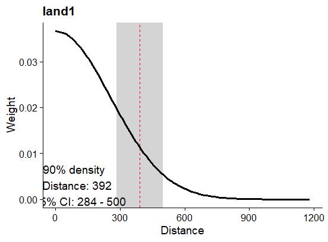

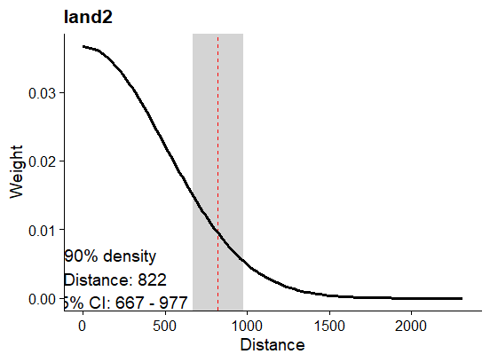

```r
## Kernel function
plot(opt2)
```

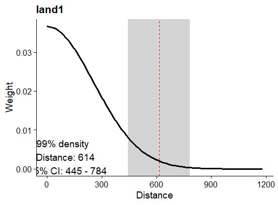

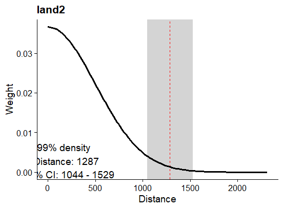

```r
## Kernel function; 99% contribution
plot(opt2, prob = 0.99)
```

In addition to the plotting the kernel function, effects plots from the fitted model object can also be generated using `plot_marginal_effects`

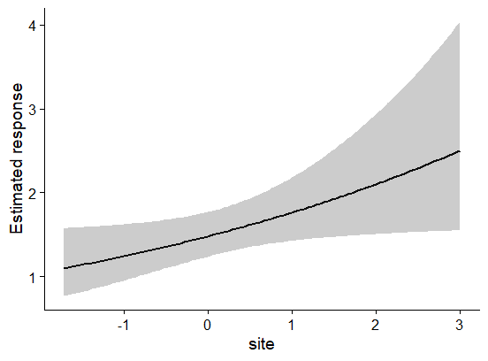

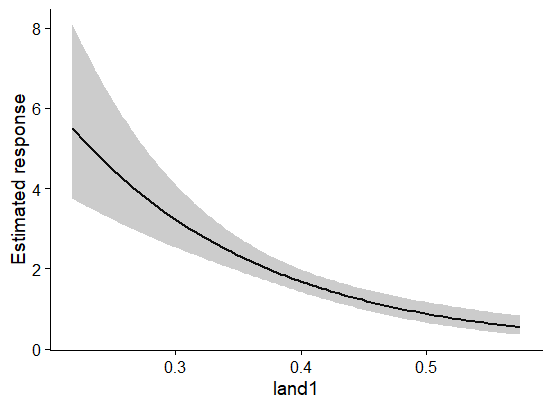

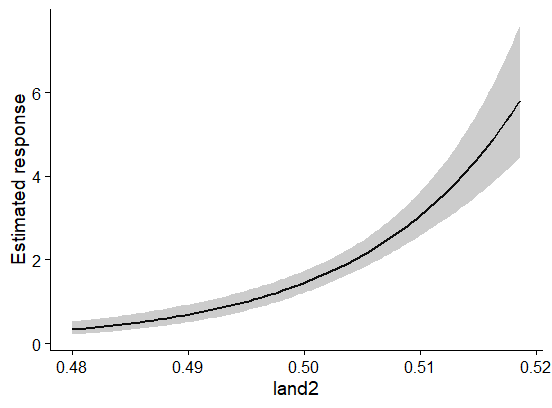

```r
plot_marginal_effects(opt2)
```

We can also apply the optimized kernel to the raster surfaces.

```r
rast_opt <- kernel_scale.raster(raster_stack = land_rast,
                                multiScaleR = opt2)
```

```
##
## Smoothing spatRaster 1 of 2: land1 at sigma = 238
##
## Smoothing spatRaster 2 of 2: land2 at sigma = 499
```

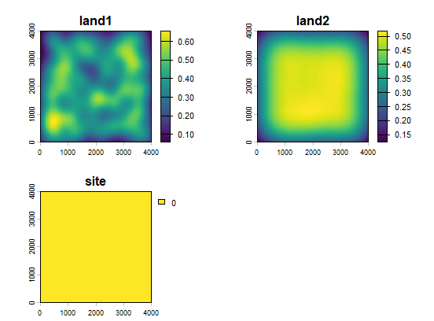

```r
plot(rast_opt)
```

## 4.2 Kernels

Data were simulated from a Gaussian kernel, but we can optimize using other kernels and compare model performance. Starting values had to be specified when using the exponential power kernel due to convergence issues.

```r
## Negative Exponential
exp_inputs <- kernel_prep(pts = pts,
                          raster_stack = land_rast,
                          max_D = 1700,
                          kernel = 'exp',
                          verbose = FALSE)

## Exponential Power
expow_inputs <- kernel_prep(pts = pts,
                            raster_stack = land_rast,
                            max_D = 1700,
                            kernel = 'expow',
                            verbose = FALSE)

## Fixed width buffer
fixed_inputs <- kernel_prep(pts = pts,
                            raster_stack = land_rast,
                            max_D = 1700,
                            kernel = 'fixed',
                            verbose = FALSE)
```

Optimize model with alternative kernels

```r
opt_exp <- multiScale_optim(fitted_mod = mod0_2,
                            kernel_inputs = exp_inputs)

## Starting values needed
opt_expow <- multiScale_optim(fitted_mod = mod0_2,
                              kernel_inputs = expow_inputs,
                              par = c(500/expow_inputs$unit_conv,
                                      500/exp_inputs$unit_conv,
                                      5,10))

opt_fixed <- multiScale_optim(fitted_mod = mod0_2,
                              kernel_inputs = fixed_inputs)
```

If you explore each of the outputs, you’ll see that we generally arrive at similar results. There are some warnings, but we won’t worry about those right now. Next, we’ll try to compare the relative support of these models using different weighted kernels.

# 5 Model Selection

With `multiScaleR` it is possible to create AIC(c) or BIC tables from lists of fitted models.

```r
mod_list <- list(opt2,
                 opt_exp,
                 opt_expow,
                 opt_fixed)

## AIC table
aic_tab(mod_list)
```

```
##
## Model selection based on AICc:
##
##                                 K   AICc Delta_AICc AICcWt Cum.Wt      LL
## [expow]~site + land1 + land2    6 316.27       0.00   0.47   0.47 -151.68
## [gaussian]~site + land1 + land2 5 316.88       0.61   0.34   0.81 -153.12
## [fixed]~site + land1 + land2    5 318.10       1.83   0.19   1.00 -153.73
## [exp]~site + land1 + land2      5 327.39      11.12   0.00   1.00 -158.38
```

```r
## BIC table
bic_tab(mod_list)
```

```
##
## Model selection based on BIC:
##
##                                 K    BIC Delta_BIC BICWt Cum.Wt      LL
## [gaussian]~site + land1 + land2 5 329.27      0.00  0.51   0.51 -153.12
## [fixed]~site + land1 + land2    5 330.48      1.22  0.28   0.78 -153.73
## [expow]~site + land1 + land2    6 331.00      1.73  0.21   1.00 -151.68
## [exp]~site + land1 + land2      5 339.78     10.51  0.00   1.00 -158.38
```

The questionably-fitting exponential power model is best-supported by AICc ranking while the Gaussian model is best-supported by BIC. Because of the added complexity (extra parameter) with the exponential power kernel, uncertain optimization, and general equivalency to other models, we should probably lean toward the simpler Gaussian kernel model. This example highlights the challenges that may be encountered when trying to parse different kernels for estimating scales of effect. From observations of performance with simulated data, use of different kernels tends to result in a similar final model and interpretation of variable effects. This, in part, is why the Gaussian kernel is the default, and likely will meet most researcher needs.

Of greater interest is using model selection to identify the best supported model in terms of parameterization (not kernel used).

```r
## Landscape only effect
mod0_3 <- glm(counts ~ land1 + land2,
              family = poisson(),
              data = df)

## Landscape 1 only effect
mod0_4 <- glm(counts ~ land1,
              family = poisson(),
              data = df)

## Landscape 2 only effect
mod0_5 <- glm(counts ~ land2,
              family = poisson(),
              data = df)

## Landscape 3 only effect
mod0_6 <- glm(counts ~ land3,
              family = poisson(),
              data = df)

## Site only effect
## No multiScaleR optimization
mod0_7 <- glm(counts ~ site,
              family = poisson(),
              data = df)
```

Optimize scale for each alternative model

```r
opt3 <- multiScale_optim(fitted_mod = mod0_3,
                         kernel_inputs = kernel_inputs)
opt4 <- multiScale_optim(fitted_mod = mod0_4,
                         kernel_inputs = kernel_inputs)
opt5 <- multiScale_optim(fitted_mod = mod0_5,
                         kernel_inputs = kernel_inputs)
opt6 <- multiScale_optim(fitted_mod = mod0_6,
                         kernel_inputs = kernel_inputs)
```

Put models into list and assess.

```r
mod_list2 <- list(opt1, opt2, opt3, opt4, opt5, opt6, mod0_7)

aic_tab(mod_list2)
```

```
##
## Model selection based on AICc:
##
##                                         K   AICc Delta_AICc AICcWt Cum.Wt
## [gaussian]~site + land1 + land2 + land3 6 316.56       0.00   0.46   0.46
## [gaussian]~site + land1 + land2         5 316.88       0.31   0.40   0.86
## [gaussian]~land1 + land2                4 318.96       2.40   0.14   1.00
## [gaussian]~land2                        3 349.41      32.85   0.00   1.00
## [gaussian]~land1                        3 393.73      77.17   0.00   1.00
## [gaussian]~land3                        3 418.64     102.08   0.00   1.00
## [NA]~site                               2 422.96     106.40   0.00   1.00
##                                              LL
## [gaussian]~site + land1 + land2 + land3 -151.83
## [gaussian]~site + land1 + land2         -153.12
## [gaussian]~land1 + land2                -155.27
## [gaussian]~land2                        -171.58
## [gaussian]~land1                        -193.74
## [gaussian]~land3                        -206.20
## [NA]~site                               -209.42
```

```r
bic_tab(mod_list2)
```

```
##
## Model selection based on BIC:
##
##                                         K    BIC Delta_BIC BICWt Cum.Wt      LL
## [gaussian]~land1 + land2                4 328.96      0.00  0.46   0.46 -155.27
## [gaussian]~site + land1 + land2         5 329.27      0.31  0.40   0.86 -153.12
## [gaussian]~site + land1 + land2 + land3 6 331.29      2.33  0.14   1.00 -151.83
## [gaussian]~land2                        3 356.98     28.02  0.00   1.00 -171.58
## [gaussian]~land1                        3 401.30     72.34  0.00   1.00 -193.74
## [gaussian]~land3                        3 426.21     97.25  0.00   1.00 -206.20
## [NA]~site                               2 428.05     99.09  0.00   1.00 -209.42
```

Model selection tables clearly show that the inclusion of scaled landscape variables is important, however information criterion may not have the greatest resolution or power to differentiate among competing models. Analyses will likely require a critical, holistic assessment of information criterion, parameter effect sizes, and precision in scale of effect estimates (i.e. sigma).

The challenge of identifying ‘significant’ scale relationships was also noted by Lowe et al., and the R package `scalescape` has a bootstrap function to determine the significance of parameters within the regression model. Such procedures are not currently implemented in `multiScaleR`.

# 6 Optimization with `unmarked`

Among the model classes that `multiScaleR` can be used to optimize are those from `unmarked`. We will use the simulation functions from the package to create data for this analysis. First, we will simulate and visualize raster surfaces.

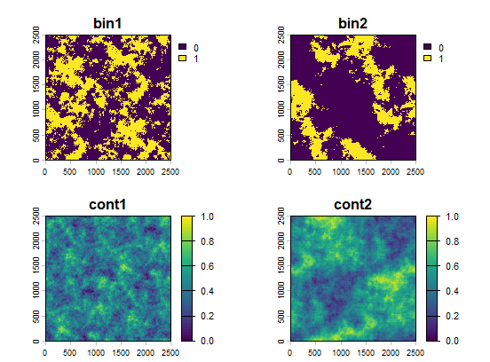

```r
rs <- sim_rast(user_seed = 999, dim = 250)
plot(rs)
```

## 6.1 Poisson Count Model

We’ll use the `bin1` and `cont2` surfaces for our data simulation. First, we’ll simulate count data with a Poisson distribution. For the `unmarked` data simulation, we need to specify the count model intercept (`alpha`), and regression coefficients that describe the effect of the raster layers (`beta`), the scale of effect (`sigma`), number of survey points on the landscape (`n_points`), the number of replicate surveys conducted (`n_surv`), the detection probability (`det`; here, the probability of detecting an individual), and the maximum distance to consider in the analysis (`max_D`).

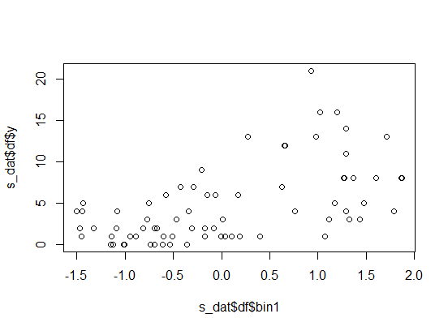

```r
rs <- terra::subset(rs, c(1,4))
s_dat <- sim_dat_unmarked(alpha = 1,
                          beta = c(0.75,-0.75),
                          kernel = 'gaussian',
                          sigma = c(75, 150),
                          n_points = 75,
                          n_surv = 5,
                          det = 0.5,
                          type = 'count',
                          raster_stack = rs,
                          max_D = 550,
                          user_seed = 555)
plot(s_dat$df$y ~ s_dat$df$bin1)
```

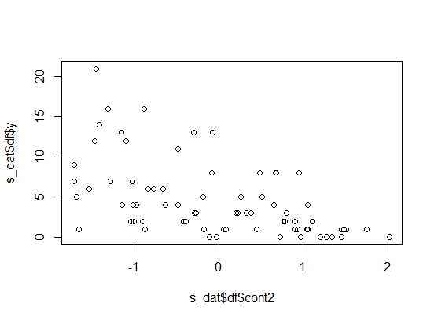

```r
plot(s_dat$df$y ~ s_dat$df$cont2)
```

We can see that we have simulated a positive effect of `bin1` on counts and negative effect of `cont2` on counts. We can now prepare data for `unmarked` and optimize scale of effect with `multiScaleR`.

```r
library(unmarked)
kernel_inputs <- kernel_prep(pts = s_dat$pts,
                             raster_stack = rs,
                             max_D = 550,
                             kernel = 'gaus',
                             verbose = FALSE)

umf <- unmarkedFramePCount(y = s_dat$y,
                           siteCovs = kernel_inputs$kernel_dat)

## Base unmarked model
mod0_umf.p <- unmarked::pcount(~1 ~bin1 + cont2,
                               data = umf,
                               K = 100)
```

```r
opt_umf.p <- multiScale_optim(fitted_mod = mod0_umf.p,
                              kernel_inputs = kernel_inputs,
                              n_cores = 8)
```

Compare optimized results with simulated values. Note that the detection reported by `unmarked` is on the logit scale, so must be back-transformed. Overall, both the scale parameters and the Poisson count model parameters were accurately recovered.

```r
summary(opt_umf.p)
```

```
##
## Call:
## multiScale_optim(fitted_mod = mod0_umf.p, kernel_inputs = kernel_inputs,
##     n_cores = 8)
##
##
## Kernel used:
## gaussian
##
## ***** Optimized Scale of Effect -- Sigma *****
##
##            Mean       SE     2.5%    97.5%
## bin1   70.37381 10.62560 49.20652  91.5411
## cont2 145.11999 25.01268 95.29217 194.9478
##
##
##   ====================================
##
## ***** Optimized Scale of Effect -- Distance *****
## 90% Kernel Weight
##
##         Mean   2.5%  97.5%
## bin1  115.75  80.94 150.57
## cont2 238.70 156.74 320.66
##
##
##   ====================================
##
##  *****     Fitted Model Summary     *****
##
##
## Call:
## unmarked::pcount(formula = ~1 ~ bin1 + cont2, data = inputs$data,
##     K = 100, mixture = "P")
##
## Abundance (log-scale):
##             Estimate     SE      z  P(>|z|)
## (Intercept)    1.070 0.0996  10.74 6.37e-27
## bin1           0.626 0.0710   8.81 1.30e-18
## cont2         -0.753 0.0716 -10.51 7.70e-26
##
## Detection (logit-scale):
##   Estimate    SE        z P(>|z|)
##  -0.000922 0.147 -0.00627   0.995
##
## AIC: 1016.524
## Number of sites: 75
```

```r
plogis(opt_umf.p$opt_mod@estimates@estimates$det@estimates[[1]])
```

```
## [1] 0.4997696
```

Assess kernel and effects plots

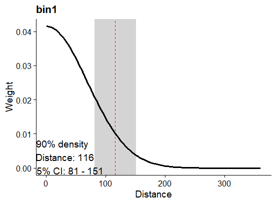

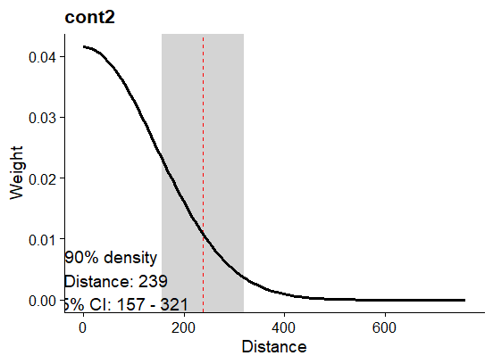

```r
plot(opt_umf.p)
```

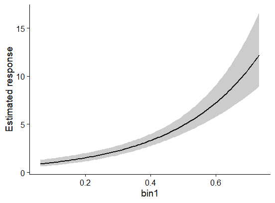

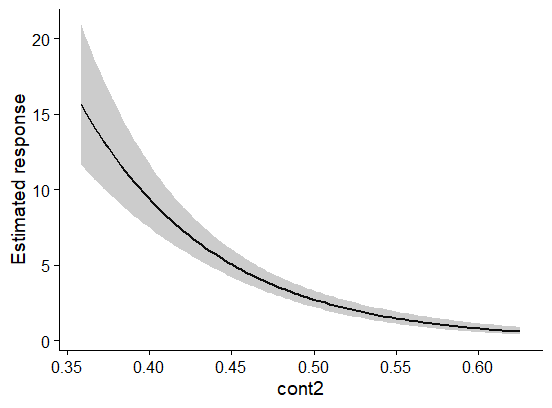

```r
plot_marginal_effects(opt_umf.p)
```

### 6.1.1 Project model

Finally, we may want to project our fitted model to the landscape to make spatial predictions. To do this, we need to scale and center our raster surfaces after applying our kernel transformations. The `spatRaster` object can then be used with the `terra::predict` function. Depending upon the spatial coverage of your sample points, you may find predicted values across a broader region unrealistic. In these instances, you may need to clamp the scaled rasters to be within a reasonable range of those observed in your sample data.

```r
## Project model
rast_scale.center <- kernel_scale.raster(raster_stack = rs,
                                         multiScaleR = opt_umf.p,
                                         scale_center = TRUE,
                                         clamp = TRUE,
                                         pct_mx = 0.00)
```

```
##
## Smoothing spatRaster 1 of 2: bin1 at sigma = 70
##
## Smoothing spatRaster 2 of 2: cont2 at sigma = 145
```

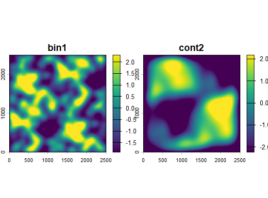

```r
plot(rast_scale.center)
```

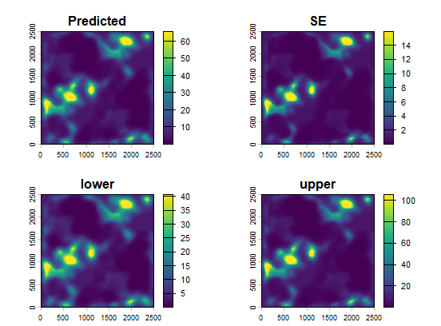

```r
ab.mod_pred <- terra::predict(rast_scale.center,
                             opt_umf.p$opt_mod,
                             type = 'state')

plot(ab.mod_pred)
```

## 6.2 Binomial Occurrence Model

Now we’ll simulate occurrence data suitable for analysis with `unmarked`. Preliminary experience has shown that simulation parameters can be harder to recover when using an occupancy model in `unmarked` with `multiScaleR`. We’ll use the same raster surfaces.

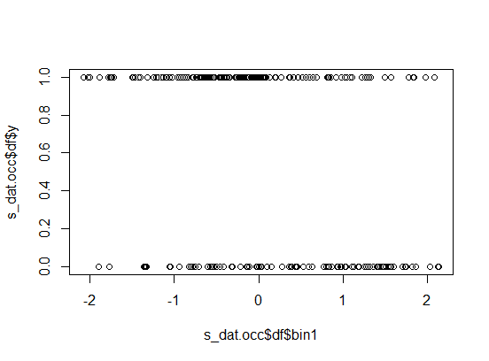

```r
s_dat.occ <- sim_dat_unmarked(alpha = 0.25,
                              beta = c(-0.75,1),
                              kernel = 'gaussian',
                              sigma = c(225, 75),
                              n_points = 250,
                              n_surv = 5,
                              det = 0.5,
                              type = 'occ',
                              raster_stack = rs,
                              max_D = 800,
                              user_seed = 555)

plot(s_dat.occ$df$y ~ s_dat.occ$df$bin1)
```

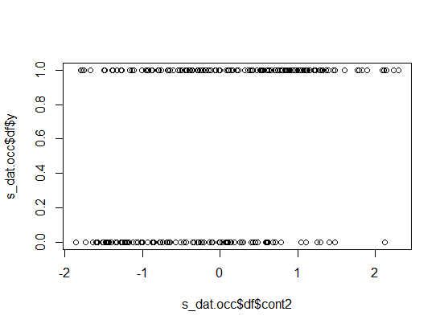

```r
plot(s_dat.occ$df$y ~ s_dat.occ$df$cont2)
```

Prepare inputs for use with `multiScaleR`

```r
kernel_inputs <- kernel_prep(pts = s_dat.occ$pts,
                             raster_stack = rs,
                             max_D = 800,
                             kernel = 'gaus',
                             verbose = FALSE)

## Occupancy frame
umf <- unmarkedFrameOccu(y = s_dat.occ$y,
                         siteCovs = kernel_inputs$kernel_dat)

## Base unmarked model
(mod0_umf.occ <- unmarked::occu(~1 ~bin1 + cont2,
                                data = umf))
```

```
##
## Call:
## unmarked::occu(formula = ~1 ~ bin1 + cont2, data = umf)
##
## Occupancy (logit-scale):
##             Estimate    SE     z  P(>|z|)
## (Intercept)    0.546 0.159  3.44 5.76e-04
## bin1          -0.829 0.175 -4.72 2.33e-06
## cont2          0.841 0.173  4.86 1.17e-06
##
## Detection (logit-scale):
##  Estimate     SE     z P(>|z|)
##     0.048 0.0785 0.612   0.541
##
## AIC: 1307.227
## Number of sites: 250
```

```r
opt_umf.occ <- multiScale_optim(fitted_mod = mod0_umf.occ,
                                kernel_inputs = kernel_inputs,
                                n_cores = 8)
```

```r
summary(opt_umf.occ)
```

```
##
## Call:
## multiScale_optim(fitted_mod = mod0_umf.occ, kernel_inputs = kernel_inputs,
##     n_cores = 8)
##
##
## Kernel used:
## gaussian
##
## ***** Optimized Scale of Effect -- Sigma *****
##
##           Mean       SE     2.5%    97.5%
## bin1  183.3404 60.39596 64.39061 302.2901
## cont2 139.1945 59.22802 22.54502 255.8440
##
##
##   ====================================
##
## ***** Optimized Scale of Effect -- Distance *****
## 90% Kernel Weight
##
##         Mean   2.5%  97.5%
## bin1  301.57 105.91 497.22
## cont2 228.95  37.08 420.83
##
##
##   ====================================
##
##  *****     Fitted Model Summary     *****
##
##
## Call:
## unmarked::occu(formula = ~1 ~ bin1 + cont2, data = inputs$data,
##     knownOcc = object@knownOcc)
##
## Occupancy (logit-scale):
##             Estimate    SE     z  P(>|z|)
## (Intercept)    0.636 0.173  3.68 2.32e-04
## bin1          -0.983 0.173 -5.67 1.41e-08
## cont2          1.009 0.200  5.04 4.78e-07
##
## Detection (logit-scale):
##  Estimate     SE     z P(>|z|)
##    0.0498 0.0783 0.637   0.524
##
## AIC: 1293.509
## Number of sites: 250
```

```r
plogis(opt_umf.occ$opt_mod@estimates@estimates$det@estimates[[1]])
```

```
## [1] 0.5124544
```

We did a decent job of recovering simulated values. Note that the sample size was increased for this simulation. Previous explorations suggested that smaller sample sizes (e.g., 100) did not contain enough information to optimize the scales of effect (`sigma`). There is opportunity for further exploration of data needs / limitations for estimating scales of effect, especially related to more complex models such those fit with `unmarked`.

### 6.2.1 Project model

```r
## Project model
rast_scale.center <- kernel_scale.raster(raster_stack = rs,
                                         multiScaleR = opt_umf.occ,
                                         scale_center = TRUE,
                                         clamp = T)
```

```
##
## Smoothing spatRaster 1 of 2: bin1 at sigma = 183
##
## Smoothing spatRaster 2 of 2: cont2 at sigma = 139
```

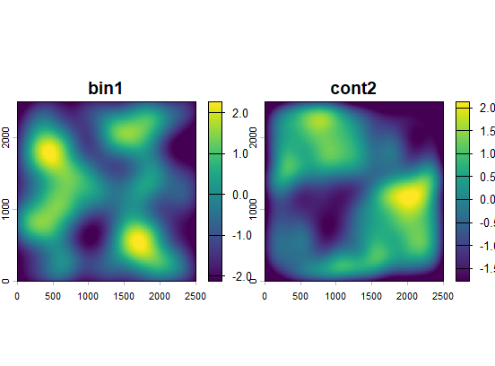

```r
plot(rast_scale.center)
```

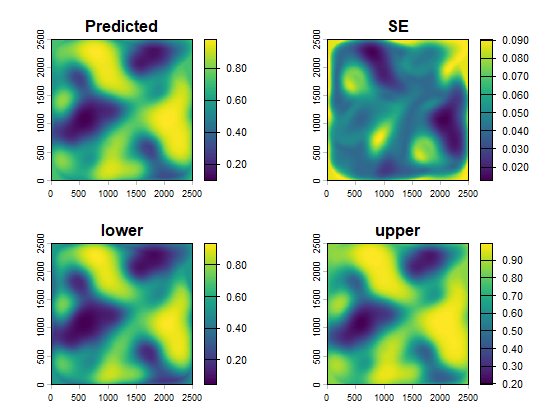

```r
occ.mod_pred <- terra::predict(rast_scale.center,
                             opt_umf.occ$opt_mod,
                             type = 'state')

plot(occ.mod_pred)
```

# 7 Other model classes

`multiScaleR` has been developed to work with any model class that has an update function. It has been tested with models fit using several different packages. If a particular model class does not work, please let me know so I can trouble shoot and try to incorporate functionality for it. In the example below, I demonstrate the fitting of a zero-inflated model with the `pscl` package. Notably, the zero-inflated term is a spatial variable that is also smoothed during the analysis. This requires some manual processing to simulate data.

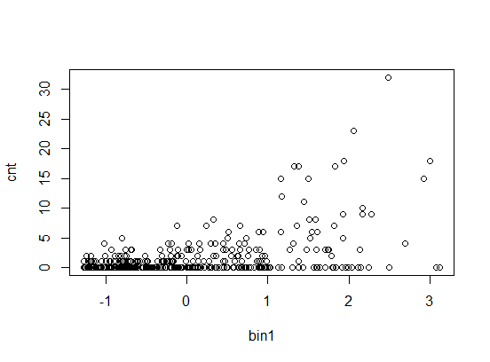

```r
set.seed(12345)
rs <- sim_rast(user_seed = 999,
               dim = 500, resolution = 30)
rs <- terra::subset(rs, c(1,3))

## Zero-inflated parameters
zi_alpha <- -0.25
zi_beta <- -1

n_points <- 400
alpha <- 0.5
beta <- 0.75
kernel <- 'gaussian'
sigma <- c(400, # For main effect, bin1
           200) # For zero-inflated, cont1
StDev <- 2  # Negative binomial dispersion

## Generate random points
bnd <- buffer(vect(ext(rs[[1]])), -1000)
pts <- spatSample(x = rs[[1]],
                  size = n_points,
                  method = 'random',
                  ext = ext(bnd),
                  replace = F,
                  as.points = T)

kernel_out <- kernel_prep(pts = pts,
                          raster_stack = rs,
                          max_D = 1500,
                          kernel = kernel,
                          sigma = sigma,
                          verbose = FALSE)

## ZINB simulation
zi_prob <- plogis(zi_alpha + zi_beta*kernel_out$kernel_dat$cont1)

# Simulate zero-inflated counts
# 1 = excess zero, 0 = from Poisson
is_zero <- rbinom(length(zi_prob), size = 1, prob = zi_prob)

obs <- exp(alpha + beta*kernel_out$kernel_dat$bin1)

obs.zinb <- ifelse(is_zero, 0,
                   rnbinom(length(is_zero),
                           mu = obs,
                           size = StDev))

dat <- data.frame(cnt = obs.zinb,
                  kernel_out$kernel_dat)
with(dat, plot(cnt ~ bin1))
```

With data generated, we can now fit our zero-inflated model and `kernel_prep` and optimize with `multiScaleR`.

```r
library(pscl)
zinb_mod <- pscl::zeroinfl(cnt ~ bin1 | cont1,
                           dist = 'negbin',
                           data = dat)

kernel_inputs <- kernel_prep(pts = pts,
                             kernel = kernel,
                             max_D = 1500,
                             raster_stack = rs,
                             verbose = FALSE)
```

**NOTE: It is highly encouraged to fit your model as `pscl::zeroinfl`.**

```r
zinb_opt <- multiScale_optim(zinb_mod,
                             kernel_inputs,
                             n_cores = 4)
```

We did a pretty good job in this simple scenario. Note the larger sample size. This was necessary to get good estimates for all parameters. Also, while `cont1` was estimated relatively accurately, there is much greater uncertainty when compared to `bin1`.

```r
summary(zinb_opt)
```

```
##
## Call:
## multiScale_optim(fitted_mod = zinb_mod, kernel_inputs = kernel_inputs,
##     n_cores = 4)
##
##
## Kernel used:
## gaussian
##
## ***** Optimized Scale of Effect -- Sigma *****
##
##           Mean       SE      2.5%    97.5%
## bin1  340.6336 45.13498 251.89872 429.3684
## cont1 180.5352 63.92097  54.86737 306.2031
##
##
##   ====================================
##
## ***** Optimized Scale of Effect -- Distance *****
## 90% Kernel Weight
##
##         Mean   2.5%  97.5%
## bin1  560.29 414.34 706.25
## cont1 296.95  90.25 503.66
##
##
##   ====================================
##
##  *****     Fitted Model Summary     *****
##
##
## Call:
## pscl::zeroinfl(formula = cnt ~ bin1 | cont1, data = dat, dist = "negbin")
##
## Pearson residuals:
##     Min      1Q  Median      3Q     Max
## -1.1449 -0.6028 -0.4006  0.3115  5.7773
##
## Count model coefficients (negbin with log link):
##             Estimate Std. Error z value Pr(>|z|)
## (Intercept)  0.51167    0.09169   5.581  2.4e-08 ***
## bin1         0.88011    0.06789  12.965  < 2e-16 ***
## Log(theta)   0.86488    0.27752   3.116  0.00183 **
##
## Zero-inflation model coefficients (binomial with logit link):
##             Estimate Std. Error z value Pr(>|z|)
## (Intercept)  -0.3549     0.2033  -1.746   0.0809 .
## cont1        -1.0701     0.2028  -5.276 1.32e-07 ***
## ---
## Signif. codes:  0 '***' 0.001 '**' 0.01 '*' 0.05 '.' 0.1 ' ' 1
##
## Theta = 2.3747
## Number of iterations in BFGS optimization: 12
## Log-likelihood: -522.8 on 5 Df
```

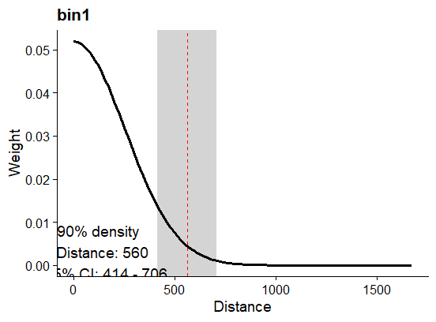

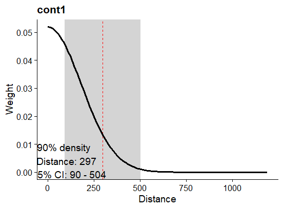

```r
plot(zinb_opt)
```

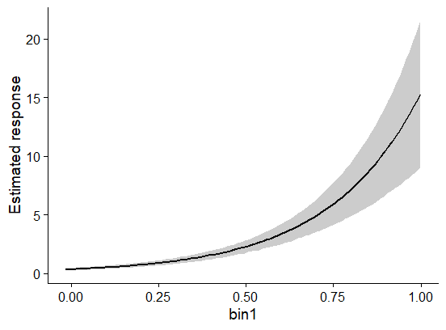

```r
plot_marginal_effects(zinb_opt)
```

# 8 Other Functions & Features

Below is a brief walk through the other functions related to scales of effect that are included with the `multiScaleR` package.

## 8.1 `kernel_dist`

In some cases, a direct assessment of scale of effect distance is desired.

```r
## With fitted model
kernel_dist(opt2)
```

```
##         Mean   2.5%  97.5%
## land1 392.22 284.00 500.44
## land2 821.66 666.67 976.65
```

```r
## Distance of 95% kernel
kernel_dist(opt2, prob = 0.95)
```

```
##         Mean   2.5%   97.5%
## land1 467.35 338.40  596.31
## land2 979.07 794.39 1163.75
```

It’s also possible to calculate the distance encompassed by specified kernels without a fitted model.

```r
kernel_dist(kernel = "gaussian", sigma = 100, prob = 0.9)
```

```
## [1] 164.49
```

```r
kernel_dist(kernel = "exp", sigma = 100, prob = 0.9)
```

```
## [1] 230.26
```

```r
kernel_dist(kernel = "expow", sigma = 100, beta = 5, prob = 0.9)
```

```
## [1] 90.44
```

## 8.2 `plot_kernel`

This is a generic function to visualize how kernel weight decays with distance

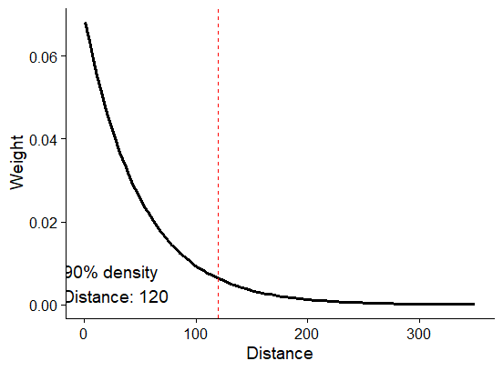

```r
plot_kernel(kernel = 'exp',
            sigma = 50)
```

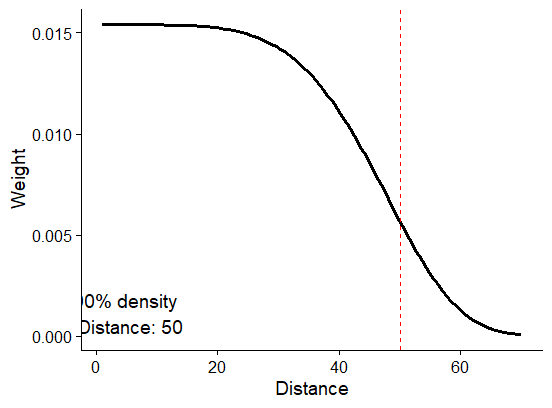

```r
plot_kernel(kernel = 'expow',
            beta = 5,
            sigma = 50)
```

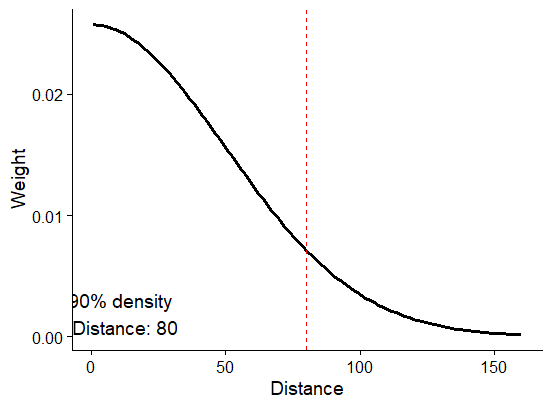

```r
plot_kernel(kernel = 'gaussian',
            sigma = 50)
```

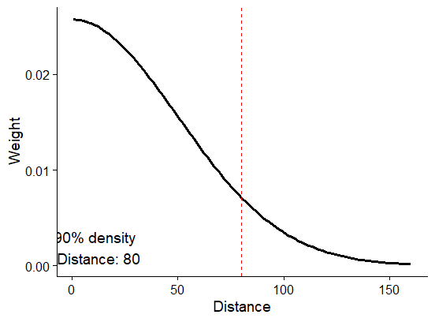

```r
plot_kernel(kernel = 'gaussian',
            sigma = 50)
```

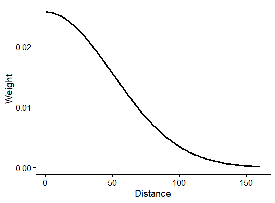

```r
plot_kernel(kernel = 'gaussian',
            sigma = 50,
            scale_dist = F)
```

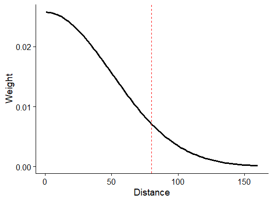

```r
plot_kernel(kernel = 'gaussian',
            sigma = 50,
            add_label = F)
```

## 8.3 `sim_rast`

Raster surfaces can be simulated that are amenable for use the `sim_dat` function.

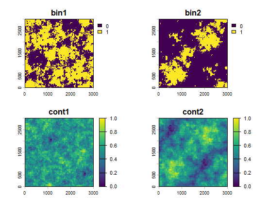

```r
r_sim1 <- sim_rast(dim = 100,
                   resolution = 30,
                   user_seed = 555)

r_sim2 <- sim_rast(dim = 100,
                   resolution = 30,
                   autocorr_range1 = 100,
                   autocorr_range2 = 1,
                   sill = 10,
                   user_seed = 555)

plot(r_sim1)
```

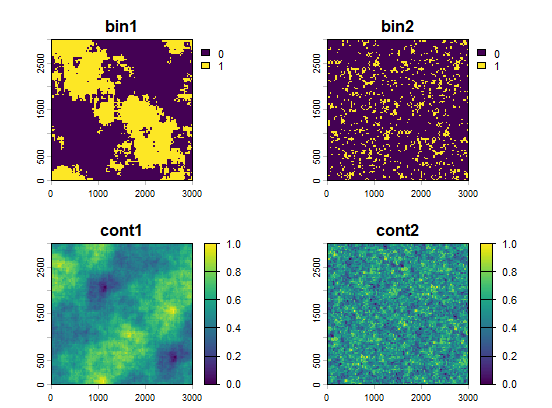

```r
plot(r_sim2)
```

## 8.4 `sim_dat`

This function will simulate data from scaled raster surfaces.

```r
s_dat <- sim_dat(alpha = 0.25,
                 beta = c(0.75, -0.75),
                 kernel = 'gaussian',
                 sigma = c(350, 200),
                 type = 'count',
                 n_points = 100,
                 raster_stack = terra::subset(r_sim1, c(1,4)),
                 min_D = 250,
                 user_seed = 999)
```

Look at the simulated covariate relationships with counts

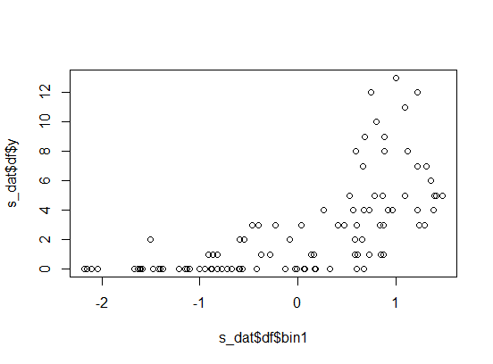

```r
plot(s_dat$df$y ~ s_dat$df$bin1)
```

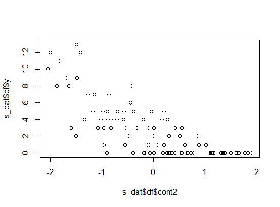

```r
plot(s_dat$df$y ~ s_dat$df$cont2)
```

Use the simulated data with `multiScaleR`

```r
sim_mod <- glm(y ~ bin1 + cont2,
               family = 'poisson',
               data = s_dat$df)

kernel_inputs <- kernel_prep(pts = s_dat$pts,
                             raster_stack = r_sim1,
                             max_D = 1500,
                             kernel = 'gaussian',
                             verbose = FALSE)
```

```r
sim_opt <- multiScale_optim(fitted_mod = sim_mod,
                            kernel_inputs = kernel_inputs)
```

Check results

```r
summary(sim_opt)
```

```
##
## Call:
## multiScale_optim(fitted_mod = sim_mod, kernel_inputs = kernel_inputs)
##
##
## Kernel used:
## gaussian
##
## ***** Optimized Scale of Effect -- Sigma *****
##
##           Mean       SE      2.5%    97.5%
## bin1  373.8632 35.31925 303.76423 443.9621
## cont2 144.6731 36.36662  72.49548 216.8508
##
##
##   ====================================
##
## ***** Optimized Scale of Effect -- Distance *****
## 90% Kernel Weight
##
##         Mean   2.5%  97.5%
## bin1  614.95 499.65 730.25
## cont2 237.97 119.24 356.69
##
##
##   ====================================
##
##  *****     Fitted Model Summary     *****
##
##
## Call:
## glm(formula = y ~ bin1 + cont2, family = "poisson", data = dat)
##
## Coefficients:
##             Estimate Std. Error z value Pr(>|z|)
## (Intercept)  0.24979    0.09909   2.521   0.0117 *
## bin1         0.75973    0.05153  14.745   <2e-16 ***
## cont2       -0.65317    0.05669 -11.521   <2e-16 ***
## ---
## Signif. codes:  0 '***' 0.001 '**' 0.01 '*' 0.05 '.' 0.1 ' ' 1
##
## (Dispersion parameter for poisson family taken to be 1)
##
##     Null deviance: 439.901  on 99  degrees of freedom
## Residual deviance:  95.606  on 97  degrees of freedom
## AIC: 286.02
##
## Number of Fisher Scoring iterations: 5
```

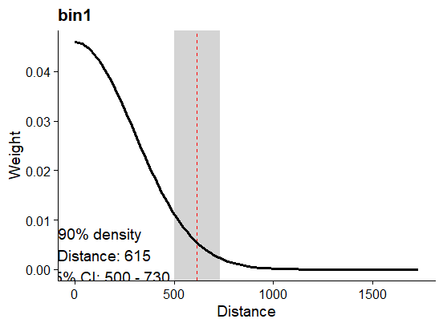

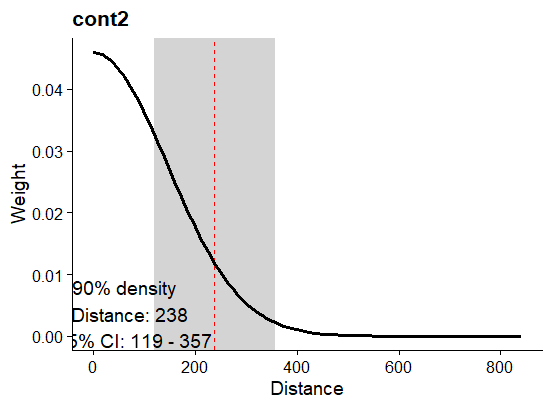

```r
plot(sim_opt)
```

```
##
## Smoothing spatRaster 1 of 2: bin1 at sigma = 373
##
## Smoothing spatRaster 2 of 2: cont2 at sigma = 144
```

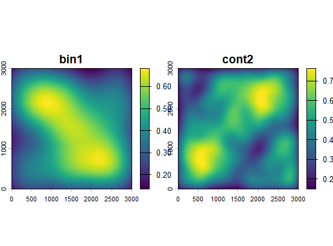

```r
plot(kernel_scale.raster(raster_stack = r_sim1,
                         multiScaleR = sim_opt))
```

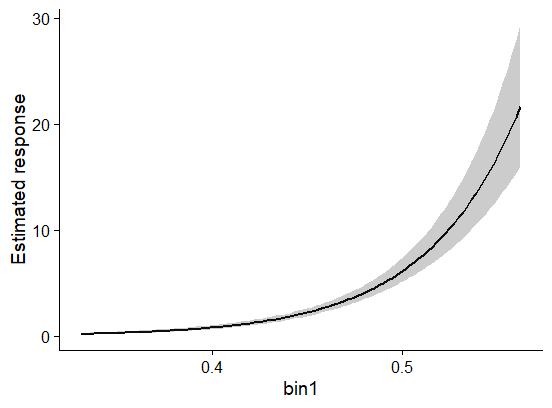

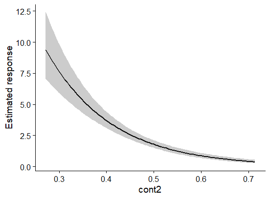

```r
plot_marginal_effects(sim_opt)
```